# Team DAY Project

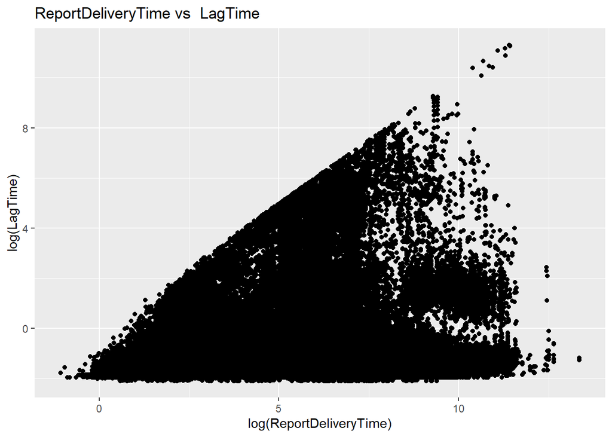

```r
reports %>% dplyr::select(ReportDeliveryTime, LagTime) %>%
ggplot(aes(x=log(ReportDeliveryTime), y=log(LagTime)))+ geom_point() + labs(title="ReportDeliveryTime vs  LagTime", x="log(ReportDeliveryTime)",y="log(LagTime)")
```

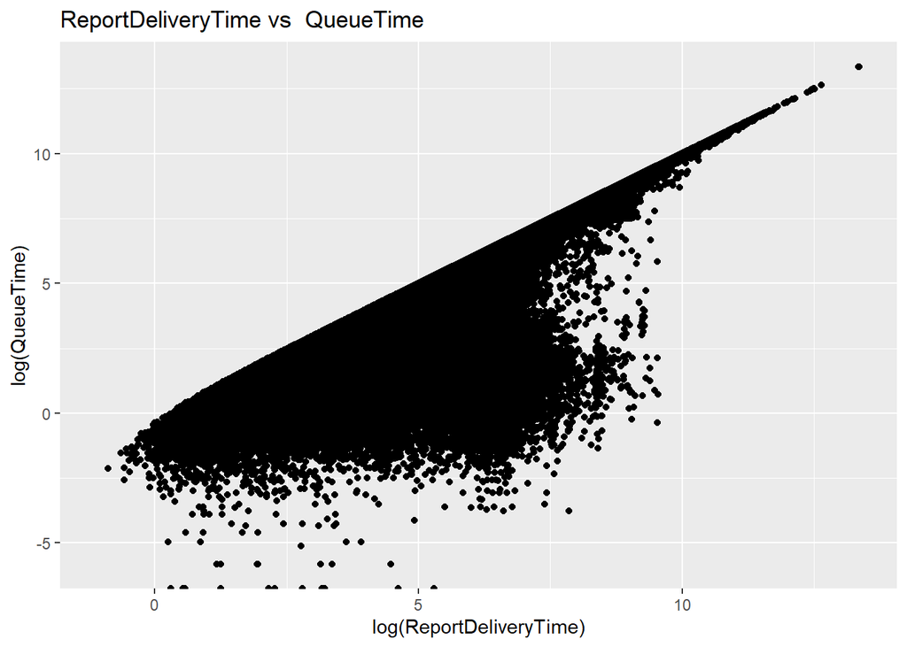

```r
reports %>% dplyr::select(ReportDeliveryTime, QueueTime) %>%
ggplot(aes(x=log(ReportDeliveryTime), y=log(QueueTime)))+ geom_point() + labs(title="ReportDeliveryTime vs  QueueTime", x="log(ReportDeliveryTime)",y="log(QueueTime)")
```

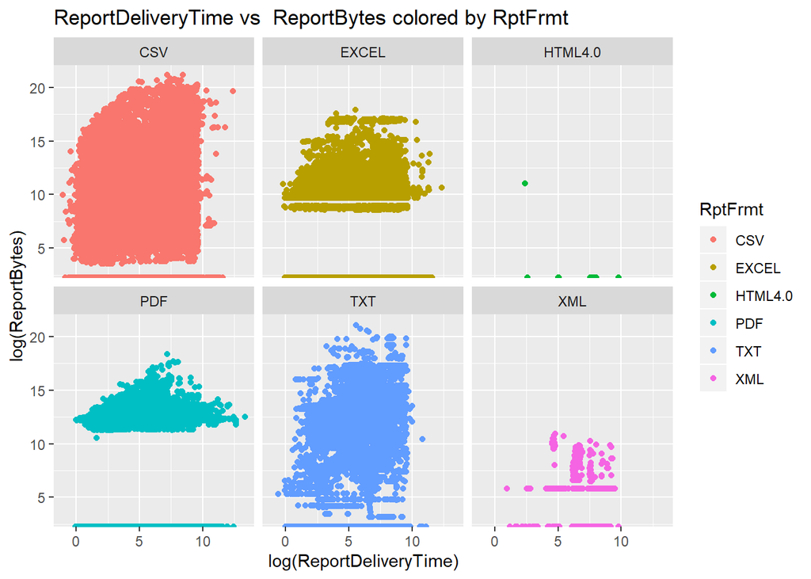

```r
reports %>% dplyr::select(ReportDeliveryTime, ReportBytes, RptFrmt) %>%
ggplot(aes(x=log(ReportDeliveryTime), y=log(ReportBytes),colour = RptFrmt ))+ geom_point() + labs(title="ReportDeliveryTime vs  ReportBytes colored by RptFrmt", x="log(ReportDeliveryTime)",y="log(ReportBytes)") + facet_wrap(~RptFrmt)
```

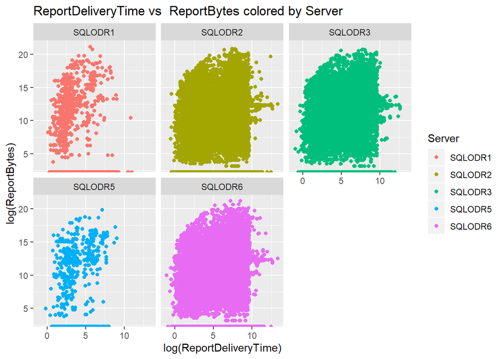

```r
reports %>% dplyr::select(ReportDeliveryTime, ReportBytes, Server) %>%
ggplot(aes(x=log(ReportDeliveryTime), y=log(ReportBytes),colour = Server ))+ geom_point() + labs(title="ReportDeliveryTime vs  ReportBytes colored by Server", x="log(ReportDeliveryTime)",y="log(ReportBytes)") + facet_wrap(~Server)
```

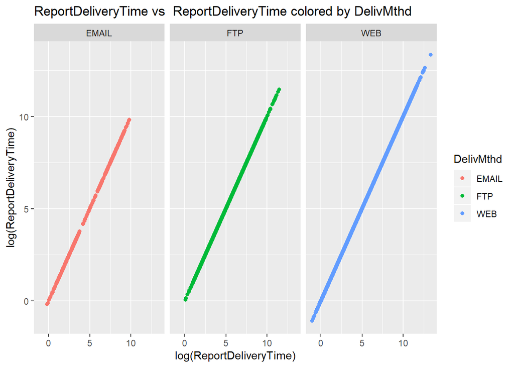

```r
reports %>% dplyr::select(ReportDeliveryTime, ReportDeliveryTime, DelivMthd) %>%
ggplot(aes(x=log(ReportDeliveryTime), y=log(ReportDeliveryTime), colour = DelivMthd))+ geom_point() + labs(title="ReportDeliveryTime vs  ReportDeliveryTime colored by DelivMthd", x="log(ReportDeliveryTime)",y="log(ReportDeliveryTime)") + facet_wrap(~DelivMthd)
```

```r
unique(reports$Agents)
```

```
##    [1] NA
##    [2] "GILSBAR,HARTFORDV,VEBAHART"
##    [3] "ARMADA"
##    [4] "TADENTE"
##    [5] "N160020383"
##    [6] "PHCSM"
##    [7] "M5001"
##    [8] "KB1659"
##    [9] "KB1034"
##   [10] "CP9446"
##   [11] "CP8216B1"
##   [12] "CP8216B"
##   [13] "CP5630"
##   [14] "CP031220"
##   [15] "CP030928"
```

[output cut: 1556 more lines]

```r
unique(reports$GroupCustom)
```

```
##  [1] NA                         "ALLGROUPS"
##  [3] "ALLSF"                    "ATHRUAZ"
##  [5] "NEBALL"                   "S0000THRUS9999"
##  [7] "NATIONWIDEALL"            "HUMANAMETLIFE"
##  [9] "HUMANAKANAWHA"            "HUMANAALL"
## [11] "TFBMCSMEDSUPP"            "ALLGROUPSEXCLUDES2612"
## [13] "TRANSAMERICATAGRPS"       "NATIONWIDERESREALL"
## [15] "TTHRUTZ"                  "ALLFI"
## [17] "HCCANDGEORGIAADS"         "GTL"
## [19] "KEMPTON"                  "MEDOVAGROUPSEXCEPTS3841"
## [21] "ACTIVECARE"               "ALLMEDCOMGROUPS"
## [23] "TEXASFB"                  "VEBA"
## [25] "NEBTRADITIONAL"           "NEBNWEELEG"
## [27] "PHIA"                     "ALLSFACTIVE"
## [29] "BENISTAR"                 "USMGU"
```

[output cut: 25 more lines]

```r
unique(reports$CurrencyCode)
```

```
##  [1] NA
##  [2] "SF"
##  [3] "NIS"
##  [4] "PAN,ACAP,ASSO,BL,PANC,KWH,CMB,ZBA2,ZBA1,FB,GFBC,GB,AHAN,IGTL,MSL,MS,MSY,MBAM,MCA,AMSC,NADA,NIS,JZA,OHP,COM,PM,RM,CS,SF,NWD,TEST,TDA,TP,TA,JUNI,USM,VEBA"
##  [5] "MCA,SF"
##  [6] "PAN,ACAP,ASSO,BL,PANC,KWH,CMB,ZBA2,ZBA1,FB,GFBC,GB,AHAN,IGTL,MSL,MS,MSY,MBAM,MCA,AMSC,NADA,NIS,JZA,OHP,COM,PM,RM,CS,SF,NWD,TEST,TDA,TP,JUNI,USM,VEBA"
##  [7] "FB"
##  [8] "PAN,ACAP,ASSO,BL,PANC,CMB,ZBA2,ZBA1,FB,GFBC,GB,AHAN,IGTL,KWH,MSL,MS,MSY,MBAM,MCA,AMSC,NADA,NIS,JZA,OHP,COM,PM,RM,CS,SF,NWD,TEST,TDA,TP,TA,JUNI,USM,VEBA"
##  [9] "ACAP,ASSO,BL,AMSC,NADA,JZA"
## [10] "KWH,TP"
## [11] "ACAP,ASSO,BL,AMSC,NADA,JZA,NWD,VEBA"
## [12] "NWD,VEBA"
## [13] "GB"
## [14] "TA"
## [15] "VEBA"
```

[output cut: 43 more lines]

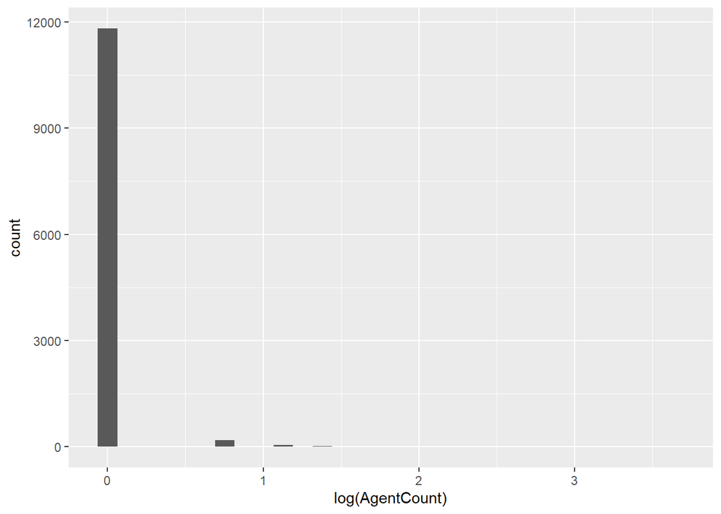

```r
reports %>% ggplot(aes(x=log(AgentCount))) + geom_histogram()
```

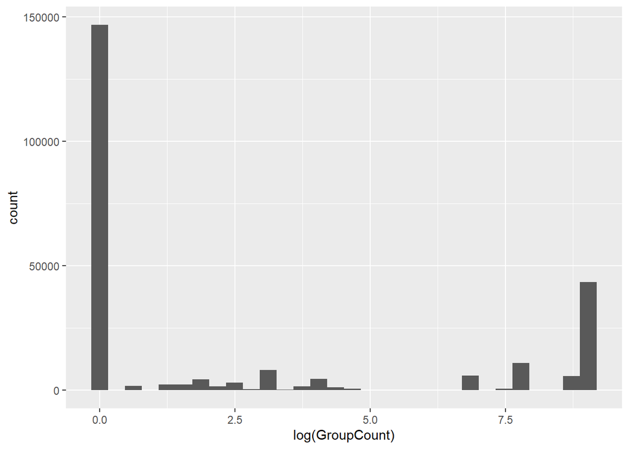

```r
reports %>% ggplot(aes(x=log(GroupCount))) + geom_histogram()
```

#Yang’s Analysis Start Here

```r
obj1.model2<-lm(ReportDeliveryTime~ReportBuildTime+LagTime+QueueTime, data=reports)
summary(obj1.model2)
```

```
##
## Call:
## lm(formula = ReportDeliveryTime ~ ReportBuildTime + LagTime +
##     QueueTime, data = reports)
##
## Residuals:
##     Min      1Q  Median      3Q     Max
## -6412.1   -20.2   -19.5   -18.2 11391.2
##
## Coefficients:
##                  Estimate Std. Error  t value Pr(>|t|)
## (Intercept)     2.017e+01  3.505e-01    57.54   <2e-16 ***
## ReportBuildTime 1.025e+00  8.306e-04  1234.32   <2e-16 ***
## LagTime         7.918e-02  7.938e-04    99.75   <2e-16 ***
## QueueTime       9.996e-01  4.700e-05 21269.14   <2e-16 ***
## ---
## Signif. codes:  0 '***' 0.001 '**' 0.01 '*' 0.05 '.' 0.1 ' ' 1
##
## Residual standard error: 168.3 on 267147 degrees of freedom
## Multiple R-squared:  0.9994, Adjusted R-squared:  0.9994
## F-statistic: 1.556e+08 on 3 and 267147 DF,  p-value: < 2.2e-16
```

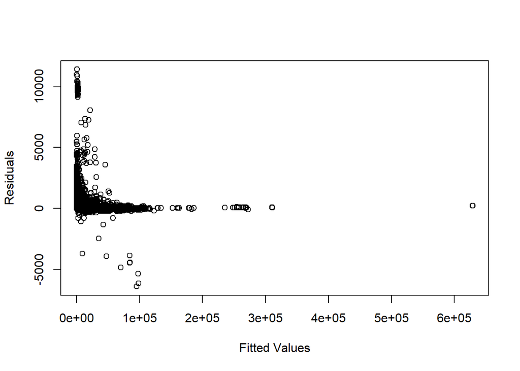

```r
plot(obj1.model2$fitted.values,obj1.model2$residuals,xlab="Fitted Values",ylab="Residuals")
```

```r
obj1.model3<-lm(ReportDeliveryTime~ReportBuildTime+LagTime+QueueTime+ReportBytes, data=reports)
summary(obj1.model3)
```

```
##
## Call:
## lm(formula = ReportDeliveryTime ~ ReportBuildTime + LagTime +
##     QueueTime + ReportBytes, data = reports)
##
## Residuals:
##     Min      1Q  Median      3Q     Max
## -6412.1   -20.2   -19.5   -18.2 11391.2
##
## Coefficients:
##                  Estimate Std. Error  t value Pr(>|t|)
## (Intercept)     2.016e+01  3.507e-01    57.50   <2e-16 ***
## ReportBuildTime 1.025e+00  8.405e-04  1219.78   <2e-16 ***
## LagTime         7.918e-02  7.938e-04    99.75   <2e-16 ***
## QueueTime       9.996e-01  4.701e-05 21266.20   <2e-16 ***
## ReportBytes     5.673e-09  2.026e-08     0.28    0.779
## ---
## Signif. codes:  0 '***' 0.001 '**' 0.01 '*' 0.05 '.' 0.1 ' ' 1
##
## Residual standard error: 168.3 on 267146 degrees of freedom
## Multiple R-squared:  0.9994, Adjusted R-squared:  0.9994
## F-statistic: 1.167e+08 on 4 and 267146 DF,  p-value: < 2.2e-16
```

```r
t(aggregate(ReportDeliveryTime~ReportCategory,data=reports,summary))
```

```
##                            [,1]            [,2]            [,3]
## ReportCategory             "Actuarial"     "Claims"        "Eligibility"
## ReportDeliveryTime.Min.    " 1.927000e+00" "-9.999990e-02" " 3.399999e-01"
## ReportDeliveryTime.1st Qu. " 1.415000e+01" " 8.037700e+01" " 8.250950e+01"
## ReportDeliveryTime.Median  " 3.171230e+02" " 5.772100e+02" " 7.397115e+02"
## ReportDeliveryTime.Mean    " 2.016336e+03" " 1.501486e+03" " 1.608286e+03"
## ReportDeliveryTime.3rd Qu. " 1.977720e+03" " 1.181380e+03" " 2.102166e+03"
## ReportDeliveryTime.Max.    " 1.865734e+05" " 3.107409e+05" " 1.342132e+05"
##                            [,4]            [,5]
## ReportCategory             "Extract"       "Finance Billing"
## ReportDeliveryTime.Min.    " 5.599999e-01" " 3.840001e-01"
## ReportDeliveryTime.1st Qu. " 1.271215e+02" " 1.141400e+02"
## ReportDeliveryTime.Median  " 7.185535e+02" " 4.632800e+02"
## ReportDeliveryTime.Mean    " 1.717402e+03" " 8.494100e+02"
## ReportDeliveryTime.3rd Qu. " 2.290688e+03" " 1.076944e+03"
## ReportDeliveryTime.Max.    " 2.481690e+05" " 3.261494e+04"
##                            [,6]                 [,7]
## ReportCategory             "Finance Commission" "Medical Management"
## ReportDeliveryTime.Min.    " 1.480000e+00"      " 9.970000e-01"
## ReportDeliveryTime.1st Qu. " 8.951650e+01"      " 5.978750e+02"
## ReportDeliveryTime.Median  " 6.159885e+02"      " 1.401997e+03"
## ReportDeliveryTime.Mean    " 1.464644e+03"      " 1.435524e+03"
## ReportDeliveryTime.3rd Qu. " 1.476676e+03"      " 1.555430e+03"
## ReportDeliveryTime.Max.    " 6.698477e+04"      " 6.293909e+05"
##                            [,8]            [,9]
## ReportCategory             "Metrics"       "Miscellaneous"
## ReportDeliveryTime.Min.    " 4.130001e-01" " 8.970001e-01"
## ReportDeliveryTime.1st Qu. " 1.308115e+02" " 8.719000e+01"
## ReportDeliveryTime.Median  " 1.359770e+03" " 5.078565e+02"
## ReportDeliveryTime.Mean    " 1.666152e+03" " 7.922855e+02"
## ReportDeliveryTime.3rd Qu. " 2.204416e+03" " 5.893785e+02"
## ReportDeliveryTime.Max.    " 5.139901e+04" " 3.658918e+04"
##                            [,10]                    [,11]
## ReportCategory             "Professional Liability" "Reinsurance"
## ReportDeliveryTime.Min.    " 9.170001e-01"          " 8.329999e-01"
## ReportDeliveryTime.1st Qu. " 6.097000e+00"          " 5.657375e+02"
## ReportDeliveryTime.Median  " 1.240000e+01"          " 5.121412e+03"
## ReportDeliveryTime.Mean    " 1.977770e+02"          " 1.552357e+04"
## ReportDeliveryTime.3rd Qu. " 2.702400e+01"          " 2.268675e+04"
## ReportDeliveryTime.Max.    " 5.984927e+04"          " 2.720550e+05"
```

This contains the time parameters can be ignored too.

```r
library(leaps)

sub <- reports %>% dplyr::select(ReportBuildTime,ReportBytes,ReportCategory,LagTime,QueueTime,ReportDeliveryTime)

#sub2 <- reports %>% select(ReportBuildTime,ReportBytes,ReportCategory,LagTime,QueueTime,ReportDeliveryTime,RptFrmt)
sub$RptFrmt = reports$RptFrmt

obj1.model4<-lm(ReportDeliveryTime~., data=sub)
summary(obj1.model4)
```

```
##
## Call:
## lm(formula = ReportDeliveryTime ~ ., data = sub)
##
## Residuals:
##     Min      1Q  Median      3Q     Max
## -6221.4   -22.1    -8.8    -1.2 11365.2
##
## Coefficients:
##                                        Estimate Std. Error   t value Pr(>|t|)
## (Intercept)                          -1.673e+00  2.209e+00    -0.757 0.448777
## ReportBuildTime                       1.027e+00  8.702e-04  1180.699  < 2e-16
## ReportBytes                           7.281e-08  1.998e-08     3.645 0.000267
## ReportCategoryClaims                  9.695e+01  2.282e+00    42.482  < 2e-16
## ReportCategoryEligibility             1.087e+01  2.281e+00     4.766 1.88e-06
## ReportCategoryExtract                -1.858e+00  2.342e+00    -0.793 0.427573
## ReportCategoryFinance Billing         5.273e+00  2.174e+00     2.425 0.015308
## ReportCategoryFinance Commission      2.024e+01  2.307e+00     8.773  < 2e-16
## ReportCategoryMedical Management     -1.386e+01  2.160e+00    -6.418 1.38e-10
## ReportCategoryMetrics                -1.400e+01  2.368e+00    -5.913 3.35e-09
## ReportCategoryMiscellaneous          -7.798e+00  3.052e+00    -2.555 0.010615
## ReportCategoryProfessional Liability  8.176e-01  3.443e+00     0.237 0.812313
## ReportCategoryReinsurance             2.172e+01  2.497e+00     8.701  < 2e-16
## LagTime                               7.689e-02  7.809e-04    98.460  < 2e-16
## QueueTime                             9.994e-01  5.170e-05 19330.239  < 2e-16
## RptFrmtEXCEL                          3.721e+01  1.147e+00    32.430  < 2e-16
## RptFrmtHTML4.0                       -9.026e+01  2.883e+01    -3.131 0.001742
## RptFrmtPDF                            1.886e+01  1.072e+00    17.592  < 2e-16
## RptFrmtTXT                            1.320e+00  1.153e+00     1.145 0.252396
## RptFrmtXML                            8.712e+00  3.195e+00     2.727 0.006401
##
## (Intercept)
## ReportBuildTime                      ***
## ReportBytes                          ***
## ReportCategoryClaims                 ***
## ReportCategoryEligibility            ***
## ReportCategoryExtract
## ReportCategoryFinance Billing        *
## ReportCategoryFinance Commission     ***
## ReportCategoryMedical Management     ***
## ReportCategoryMetrics                ***
## ReportCategoryMiscellaneous          *
## ReportCategoryProfessional Liability
## ReportCategoryReinsurance            ***
## LagTime                              ***
## QueueTime                            ***
## RptFrmtEXCEL                         ***
## RptFrmtHTML4.0                       **
## RptFrmtPDF                           ***
## RptFrmtTXT
## RptFrmtXML                           **
## ---
## Signif. codes:  0 '***' 0.001 '**' 0.01 '*' 0.05 '.' 0.1 ' ' 1
##
## Residual standard error: 165.4 on 267131 degrees of freedom
## Multiple R-squared:  0.9994, Adjusted R-squared:  0.9994
## F-statistic: 2.542e+07 on 19 and 267131 DF,  p-value: < 2.2e-16
```

```r
#reg.fwd=regsubsets(ReportBuildTime~.,data=sub,method="forward",nvmax=4)

obj1.model4<-lm(ReportDeliveryTime~ReportBuildTime+ReportBytes+ReportCategory+LagTime+QueueTime+RptFrmt, data=reports)
summary(obj1.model4)
```

```
##
## Call:
## lm(formula = ReportDeliveryTime ~ ReportBuildTime + ReportBytes +
##     ReportCategory + LagTime + QueueTime + RptFrmt, data = reports)
##
## Residuals:
##     Min      1Q  Median      3Q     Max
## -6221.4   -22.1    -8.8    -1.2 11365.2
##
## Coefficients:
##                                        Estimate Std. Error   t value Pr(>|t|)
## (Intercept)                          -1.673e+00  2.209e+00    -0.757 0.448777
## ReportBuildTime                       1.027e+00  8.702e-04  1180.699  < 2e-16
## ReportBytes                           7.281e-08  1.998e-08     3.645 0.000267
## ReportCategoryClaims                  9.695e+01  2.282e+00    42.482  < 2e-16
## ReportCategoryEligibility             1.087e+01  2.281e+00     4.766 1.88e-06
## ReportCategoryExtract                -1.858e+00  2.342e+00    -0.793 0.427573
## ReportCategoryFinance Billing         5.273e+00  2.174e+00     2.425 0.015308
## ReportCategoryFinance Commission      2.024e+01  2.307e+00     8.773  < 2e-16
## ReportCategoryMedical Management     -1.386e+01  2.160e+00    -6.418 1.38e-10
## ReportCategoryMetrics                -1.400e+01  2.368e+00    -5.913 3.35e-09
## ReportCategoryMiscellaneous          -7.798e+00  3.052e+00    -2.555 0.010615
## ReportCategoryProfessional Liability  8.176e-01  3.443e+00     0.237 0.812313
## ReportCategoryReinsurance             2.172e+01  2.497e+00     8.701  < 2e-16
## LagTime                               7.689e-02  7.809e-04    98.460  < 2e-16
## QueueTime                             9.994e-01  5.170e-05 19330.239  < 2e-16
## RptFrmtEXCEL                          3.721e+01  1.147e+00    32.430  < 2e-16
## RptFrmtHTML4.0                       -9.026e+01  2.883e+01    -3.131 0.001742
## RptFrmtPDF                            1.886e+01  1.072e+00    17.592  < 2e-16
## RptFrmtTXT                            1.320e+00  1.153e+00     1.145 0.252396
## RptFrmtXML                            8.712e+00  3.195e+00     2.727 0.006401
##
## (Intercept)
## ReportBuildTime                      ***
## ReportBytes                          ***
## ReportCategoryClaims                 ***
## ReportCategoryEligibility            ***
## ReportCategoryExtract
## ReportCategoryFinance Billing        *
## ReportCategoryFinance Commission     ***
## ReportCategoryMedical Management     ***
## ReportCategoryMetrics                ***
## ReportCategoryMiscellaneous          *
## ReportCategoryProfessional Liability
## ReportCategoryReinsurance            ***
## LagTime                              ***
## QueueTime                            ***
## RptFrmtEXCEL                         ***
## RptFrmtHTML4.0                       **
## RptFrmtPDF                           ***
## RptFrmtTXT
## RptFrmtXML                           **
## ---
## Signif. codes:  0 '***' 0.001 '**' 0.01 '*' 0.05 '.' 0.1 ' ' 1
##
## Residual standard error: 165.4 on 267131 degrees of freedom
## Multiple R-squared:  0.9994, Adjusted R-squared:  0.9994
## F-statistic: 2.542e+07 on 19 and 267131 DF,  p-value: < 2.2e-16
```

```r
reports_new <- reports
reports_new <- within(reports_new, rm(ReportId,QueuedDateTime,RenderStartDateTime,ReportStartDateTime,ReportEndDateTime, RenderEndDateTime,GroupCustom,CurrencyCode,groupSF,groupFI,Agents))

obj1.model5<-lm(ReportDeliveryTime~., data=reports_new)
summary(obj1.model5)
```

```
##
## Call:
## lm(formula = ReportDeliveryTime ~ ., data = reports_new)
##
## Residuals:
##     Min      1Q  Median      3Q     Max
## -6109.9   -25.9    -6.7     6.9 11254.9
##
## Coefficients: (1 not defined because of singularities)
##                                        Estimate Std. Error   t value Pr(>|t|)
## (Intercept)                           1.116e+02  3.742e+01     2.981 0.002869
## SchedFreqOneTime                     -1.444e+01  1.443e+00   -10.010  < 2e-16
## SchedFreqWeek                        -3.102e+01  1.435e+00   -21.624  < 2e-16
## ServerSQLODR2                         1.753e+02  3.172e+01     5.528 3.25e-08
## ServerSQLODR3                         1.775e+02  3.172e+01     5.595 2.21e-08
## ServerSQLODR5                         4.463e+01  7.076e+00     6.307 2.85e-10
## ServerSQLODR6                         1.725e+02  3.172e+01     5.439 5.37e-08
## RptFrmtEXCEL                          4.142e+01  1.267e+00    32.681  < 2e-16
## RptFrmtHTML4.0                       -7.329e+01  2.860e+01    -2.563 0.010381
## RptFrmtPDF                            2.127e+01  1.163e+00    18.293  < 2e-16
## RptFrmtTXT                            1.181e+01  1.518e+00     7.775 7.59e-15
## RptFrmtXML                            2.553e+01  3.546e+00     7.201 5.98e-13
## DelivMthdFTP                         -4.325e+00  4.199e+00    -1.030 0.302963
## DelivMthdWEB                         -1.851e+00  3.950e+00    -0.468 0.639431
## TestProdIndicatorP                   -1.733e+02  3.142e+01    -5.516 3.48e-08
## TestProdIndicatorT                           NA         NA        NA       NA
## ReportBytes                           5.248e-08  1.986e-08     2.642 0.008234
## Priority1                            -2.051e+02  1.294e+01   -15.855  < 2e-16
## Priority2                            -1.303e+02  1.286e+01   -10.128  < 2e-16
## Priority3                            -1.528e+02  1.316e+01   -11.611  < 2e-16
## Priority10                           -1.513e+02  1.269e+01   -11.926  < 2e-16
## AgentCount                           -3.874e+01  1.595e+00   -24.297  < 2e-16
## GroupCount                           -8.536e-04  1.312e-04    -6.505 7.76e-11
## ReportCategoryClaims                  1.039e+02  2.282e+00    45.537  < 2e-16
## ReportCategoryEligibility             2.782e+01  2.345e+00    11.860  < 2e-16
## ReportCategoryExtract                 1.451e+01  2.411e+00     6.017 1.78e-09
## ReportCategoryFinance Billing         7.308e+01  3.321e+00    22.006  < 2e-16
## ReportCategoryFinance Commission      1.011e+02  3.511e+00    28.791  < 2e-16
## ReportCategoryMedical Management      1.593e+01  3.896e+00     4.088 4.35e-05
## ReportCategoryMetrics                 2.833e+00  2.595e+00     1.092 0.274898
```

[output cut: 152 more lines]

```
## HourOfDay15
## HourOfDay16
## HourOfDay17
## HourOfDay18
## HourOfDay19
## HourOfDay20                          **
## HourOfDay21                          .
## HourOfDay22
## HourOfDay23
## ---
## Signif. codes:  0 '***' 0.001 '**' 0.01 '*' 0.05 '.' 0.1 ' ' 1
##
## Residual standard error: 164 on 267057 degrees of freedom
## Multiple R-squared:  0.9995, Adjusted R-squared:  0.9995
## F-statistic: 5.284e+06 on 93 and 267057 DF,  p-value: < 2.2e-16
```

Official Analysis from this down: -Removed the time related parameters -Removed other servers, left with 2, 3, 6 -Removed TestProdIndicator other than P

```r
reports_serv <- reports %>% filter(Server == "SQLODR6"| Server == "SQLODR2"|  Server == "SQLODR3")
reports_serv <- reports_serv %>% filter(TestProdIndicator == "P")
reports_serv_new <- within(reports_serv,
rm(ReportId,QueuedDateTime,RenderStartDateTime,ReportStartDateTime,ReportEndDateTime, RenderEndDateTime,GroupCustom,CurrencyCode,groupSF,groupFI,ReportBuildTime,QueueTime,LagTime,Totaltime,Agents,TestProdIndicator,ReportBytes))
#Drop levels of unused server names
table(droplevels(reports_serv_new)$Server)
```

```
##
## SQLODR2 SQLODR3 SQLODR6
##   92388   76354   95404
```

```r
reports_serv_new$Server <- factor(reports_serv_new$Server)
levels(reports_serv_new$Server)
```

```
## [1] "SQLODR2" "SQLODR3" "SQLODR6"
```

```r
all_model<-lm(ReportDeliveryTime~., data=reports_serv_new)
summary(all_model)
```

```
##
## Call:
## lm(formula = ReportDeliveryTime ~ ., data = reports_serv_new)
##
## Residuals:
##    Min     1Q Median     3Q    Max
## -27485  -1044     36    769 624626
##
## Coefficients:
##                                        Estimate Std. Error t value Pr(>|t|)
## (Intercept)                           5.806e+04  1.220e+03  47.595  < 2e-16 ***
## SchedFreqOneTime                     -3.960e+03  4.913e+01 -80.605  < 2e-16 ***
## SchedFreqWeek                        -2.332e+03  4.920e+01 -47.409  < 2e-16 ***
## ServerSQLODR3                         1.555e+01  2.768e+01   0.562 0.574295
## ServerSQLODR6                        -8.614e+01  2.607e+01  -3.304 0.000955 ***
## RptFrmtEXCEL                         -8.925e+02  4.372e+01 -20.413  < 2e-16 ***
## RptFrmtHTML4.0                        8.437e+02  9.833e+02   0.858 0.390867
## RptFrmtPDF                            2.284e+02  4.007e+01   5.699 1.20e-08 ***
## RptFrmtTXT                           -1.461e+02  5.286e+01  -2.764 0.005712 **
## RptFrmtXML                            1.978e+02  1.227e+02   1.612 0.106966
## DelivMthdFTP                         -1.646e+02  1.449e+02  -1.136 0.255881
## DelivMthdWEB                         -1.055e+02  1.362e+02  -0.775 0.438621
## Priority2                            -7.611e+01  1.310e+02  -0.581 0.561098
## Priority3                             2.301e+02  1.518e+02   1.516 0.129484
## Priority10                            6.736e+02  9.043e+01   7.448 9.47e-14 ***
## AgentCount                            4.560e+02  5.487e+01   8.309  < 2e-16 ***
## GroupCount                           -3.351e-02  4.520e-03  -7.414 1.23e-13 ***
## ReportCategoryClaims                 -2.399e+02  7.876e+01  -3.046 0.002321 **
## ReportCategoryEligibility             1.333e+02  8.106e+01   1.645 0.100035
## ReportCategoryExtract                 5.539e+02  8.338e+01   6.643 3.09e-11 ***
## ReportCategoryFinance Billing         1.202e+02  1.146e+02   1.049 0.294307
## ReportCategoryFinance Commission      4.171e+02  1.212e+02   3.441 0.000580 ***
## ReportCategoryMedical Management      3.579e+01  1.353e+02   0.264 0.791451
## ReportCategoryMetrics                 4.156e+02  8.937e+01   4.650 3.32e-06 ***
## ReportCategoryMiscellaneous          -7.049e+02  1.075e+02  -6.558 5.48e-11 ***
## ReportCategoryProfessional Liability  4.751e+02  1.557e+02   3.051 0.002283 **
## ReportCategoryReinsurance             9.796e+03  8.470e+01 115.658  < 2e-16 ***
## DayOfMonth02                         -4.404e+02  5.997e+01  -7.344 2.08e-13 ***
## DayOfMonth03                         -2.855e+03  6.747e+01 -42.311  < 2e-16 ***
## DayOfMonth04                         -9.671e+02  6.943e+01 -13.929  < 2e-16 ***
```

[output cut: 47 more lines]

```
## HourOfDay15                          -5.223e+04  1.206e+03 -43.324  < 2e-16 ***
## HourOfDay16                          -5.164e+04  1.206e+03 -42.808  < 2e-16 ***
## HourOfDay17                          -5.109e+04  1.207e+03 -42.322  < 2e-16 ***
## HourOfDay18                          -5.438e+04  1.204e+03 -45.149  < 2e-16 ***
## HourOfDay19                          -5.222e+04  1.207e+03 -43.284  < 2e-16 ***
## HourOfDay20                          -4.899e+04  1.218e+03 -40.225  < 2e-16 ***
## HourOfDay21                          -5.197e+04  1.210e+03 -42.935  < 2e-16 ***
## HourOfDay22                          -4.451e+04  1.225e+03 -36.330  < 2e-16 ***
## HourOfDay23                          -4.870e+04  1.235e+03 -39.425  < 2e-16 ***
## ---
## Signif. codes:  0 '***' 0.001 '**' 0.01 '*' 0.05 '.' 0.1 ' ' 1
##
## Residual standard error: 5638 on 264060 degrees of freedom
## Multiple R-squared:  0.3641, Adjusted R-squared:  0.3639
## F-statistic:  1778 on 85 and 264060 DF,  p-value: < 2.2e-16
```

```r
#par(mfrow=c(2,2))
#plot(all_model)


reg.fwd=regsubsets(ReportDeliveryTime~.,data=reports_serv_new,method="forward",nvmax=4)
```

```
## Reordering variables and trying again:
```

```r
summary(reg.fwd)
```

```
## Subset selection object
## Call: regsubsets.formula(ReportDeliveryTime ~ ., data = reports_serv_new,
##     method = "forward", nvmax = 4)
## 86 Variables  (and intercept)
##                                      Forced in Forced out
## SchedFreqOneTime                         FALSE      FALSE
## SchedFreqWeek                            FALSE      FALSE
## ServerSQLODR3                            FALSE      FALSE
## ServerSQLODR6                            FALSE      FALSE
## RptFrmtEXCEL                             FALSE      FALSE
## RptFrmtHTML4.0                           FALSE      FALSE
## RptFrmtPDF                               FALSE      FALSE
## RptFrmtTXT                               FALSE      FALSE
## RptFrmtXML                               FALSE      FALSE
## DelivMthdFTP                             FALSE      FALSE
## DelivMthdWEB                             FALSE      FALSE
## Priority1                                FALSE      FALSE
## Priority2                                FALSE      FALSE
## Priority3                                FALSE      FALSE
## AgentCount                               FALSE      FALSE
## GroupCount                               FALSE      FALSE
## ReportCategoryClaims                     FALSE      FALSE
## ReportCategoryEligibility                FALSE      FALSE
## ReportCategoryExtract                    FALSE      FALSE
## ReportCategoryFinance Billing            FALSE      FALSE
## ReportCategoryFinance Commission         FALSE      FALSE
## ReportCategoryMedical Management         FALSE      FALSE
## ReportCategoryMetrics                    FALSE      FALSE
## ReportCategoryMiscellaneous              FALSE      FALSE
## ReportCategoryProfessional Liability     FALSE      FALSE
## ReportCategoryReinsurance                FALSE      FALSE
## DayOfMonth02                             FALSE      FALSE
## DayOfMonth03                             FALSE      FALSE
## DayOfMonth04                             FALSE      FALSE
## DayOfMonth05                             FALSE      FALSE
## DayOfMonth06                             FALSE      FALSE
## DayOfMonth07                             FALSE      FALSE
## DayOfMonth08                             FALSE      FALSE
## DayOfMonth09                             FALSE      FALSE
## DayOfMonth10                             FALSE      FALSE
```

[output cut: 164 more lines]

```
## 3  ( 1 ) " "         " "         " "         " "         " "
## 4  ( 1 ) " "         " "         " "         " "         " "
## 5  ( 1 ) " "         " "         " "         " "         " "
##          HourOfDay18 HourOfDay19 HourOfDay20 HourOfDay21 HourOfDay22
## 1  ( 1 ) " "         " "         " "         " "         " "
## 2  ( 1 ) " "         " "         " "         " "         " "
## 3  ( 1 ) " "         " "         " "         " "         " "
## 4  ( 1 ) " "         " "         " "         " "         " "
## 5  ( 1 ) " "         " "         " "         " "         " "
##          HourOfDay23
## 1  ( 1 ) " "
## 2  ( 1 ) " "
## 3  ( 1 ) " "
## 4  ( 1 ) " "
## 5  ( 1 ) " "
```

```r
reg.fwdnv20=regsubsets(ReportDeliveryTime~.,data=reports_serv_new,method="forward",nvmax=20)
```

```
## Reordering variables and trying again:
```

```r
summary(reg.fwdnv20)
```

```
## Subset selection object
## Call: regsubsets.formula(ReportDeliveryTime ~ ., data = reports_serv_new,
##     method = "forward", nvmax = 20)
## 86 Variables  (and intercept)
##                                      Forced in Forced out
## SchedFreqOneTime                         FALSE      FALSE
## SchedFreqWeek                            FALSE      FALSE
## ServerSQLODR3                            FALSE      FALSE
## ServerSQLODR6                            FALSE      FALSE
## RptFrmtEXCEL                             FALSE      FALSE
## RptFrmtHTML4.0                           FALSE      FALSE
## RptFrmtPDF                               FALSE      FALSE
## RptFrmtTXT                               FALSE      FALSE
## RptFrmtXML                               FALSE      FALSE
## DelivMthdFTP                             FALSE      FALSE
```

[output cut: 540 more lines]

```r
summary(reg.fwdnv20)$adjr2
```

```
##  [1] 0.2008961 0.2221920 0.2421847 0.2580362 0.2724118 0.2838699 0.2947675
##  [8] 0.3153993 0.3262596 0.3294812 0.3329065 0.3358410 0.3387032 0.3408841
## [15] 0.3420521 0.3431324 0.3441115 0.3447686 0.3453302 0.3459065 0.3463649
```

```r
summary(reg.fwdnv20)$rss
```

```
##  [1] 1.054896e+13 1.026779e+13 1.000383e+13 9.794540e+12 9.604734e+12
##  [6] 9.453442e+12 9.309550e+12 9.037162e+12 8.893766e+12 8.851205e+12
## [11] 8.805956e+12 8.767186e+12 8.729371e+12 8.700550e+12 8.685099e+12
## [16] 8.670806e+12 8.657848e+12 8.649141e+12 8.641696e+12 8.634055e+12
## [21] 8.627973e+12
```

```r
summary(reg.fwdnv20)$bic
```

```
##  [1]  -59214.56  -66337.99  -73204.86  -78777.22  -83933.81  -88115.23
##  [7]  -92154.25  -99985.73 -104198.17 -105452.77 -106794.12 -107947.15
## [13] -109076.47 -109937.54 -110394.56 -110817.14 -111199.68 -111452.98
## [19] -111667.97 -111889.13 -112062.81
```

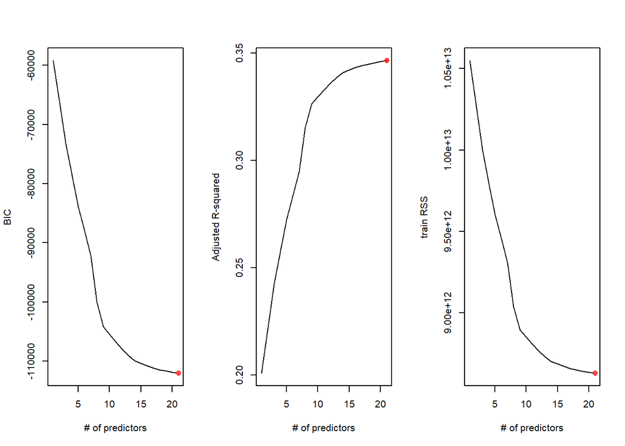

```r
par(mfrow=c(1,3))
bics<-summary(reg.fwdnv20)$bic
plot(1:21,bics,type="l",ylab="BIC",xlab="# of predictors")
index<-which(bics==min(bics))
points(index,bics[index],col="red",pch=10)

adjr2<-summary(reg.fwdnv20)$adjr2
plot(1:21,adjr2,type="l",ylab="Adjusted R-squared",xlab="# of predictors")
index<-which(adjr2==max(adjr2))
points(index,adjr2[index],col="red",pch=10)

rss<-summary(reg.fwdnv20)$rss
plot(1:21,rss,type="l",ylab="train RSS",xlab="# of predictors")
index<-which(rss==min(rss))
points(index,rss[index],col="red",pch=10)
```

```r
reg.fwdnv50=regsubsets(ReportDeliveryTime~.,data=reports_serv_new,method="forward",nvmax=50)
```

```
## Reordering variables and trying again:
```

```r
summary(reg.fwdnv50)
```

```
## Subset selection object
## Call: regsubsets.formula(ReportDeliveryTime ~ ., data = reports_serv_new,
##     method = "forward", nvmax = 50)
## 86 Variables  (and intercept)
##                                      Forced in Forced out
## SchedFreqOneTime                         FALSE      FALSE
## SchedFreqWeek                            FALSE      FALSE
## ServerSQLODR3                            FALSE      FALSE
## ServerSQLODR6                            FALSE      FALSE
## RptFrmtEXCEL                             FALSE      FALSE
## RptFrmtHTML4.0                           FALSE      FALSE
## RptFrmtPDF                               FALSE      FALSE
## RptFrmtTXT                               FALSE      FALSE
## RptFrmtXML                               FALSE      FALSE
## DelivMthdFTP                             FALSE      FALSE
```

[output cut: 1170 more lines]

```r
summary(reg.fwdnv50)$adjr2
```

```
##  [1] 0.2008961 0.2221920 0.2421847 0.2580362 0.2724118 0.2838699 0.2947675
##  [8] 0.3153993 0.3262596 0.3294812 0.3329065 0.3358410 0.3387032 0.3408841
## [15] 0.3420521 0.3431324 0.3441115 0.3447686 0.3453302 0.3459065 0.3463649
## [22] 0.3467364 0.3470764 0.3473963 0.3476782 0.3479534 0.3482540 0.3485002
## [29] 0.3487148 0.3489034 0.3491854 0.3493665 0.3495335 0.3496970 0.3498568
## [36] 0.3500020 0.3501331 0.3502632 0.3503780 0.3504830 0.3505996 0.3506985
## [43] 0.3507862 0.3508804 0.3509837 0.3510955 0.3512064 0.3513324 0.3514742
## [50] 0.3516367 0.3518265
```

```r
summary(reg.fwdnv20)$rss
```

```
##  [1] 1.054896e+13 1.026779e+13 1.000383e+13 9.794540e+12 9.604734e+12
##  [6] 9.453442e+12 9.309550e+12 9.037162e+12 8.893766e+12 8.851205e+12
## [11] 8.805956e+12 8.767186e+12 8.729371e+12 8.700550e+12 8.685099e+12
## [16] 8.670806e+12 8.657848e+12 8.649141e+12 8.641696e+12 8.634055e+12
## [21] 8.627973e+12
```

```r
summary(reg.fwdnv20)$bic
```

```
##  [1]  -59214.56  -66337.99  -73204.86  -78777.22  -83933.81  -88115.23
##  [7]  -92154.25  -99985.73 -104198.17 -105452.77 -106794.12 -107947.15
## [13] -109076.47 -109937.54 -110394.56 -110817.14 -111199.68 -111452.98
## [19] -111667.97 -111889.13 -112062.81
```

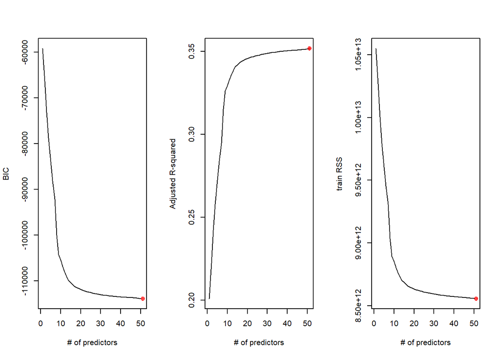

```r
par(mfrow=c(1,3))
bics<-summary(reg.fwdnv50)$bic
plot(1:51,bics,type="l",ylab="BIC",xlab="# of predictors")
index<-which(bics==min(bics))
points(index,bics[index],col="red",pch=10)

adjr2<-summary(reg.fwdnv50)$adjr2
plot(1:51,adjr2,type="l",ylab="Adjusted R-squared",xlab="# of predictors")
index<-which(adjr2==max(adjr2))
points(index,adjr2[index],col="red",pch=10)

rss<-summary(reg.fwdnv50)$rss
plot(1:51,rss,type="l",ylab="train RSS",xlab="# of predictors")
index<-which(rss==min(rss))
points(index,rss[index],col="red",pch=10)
```

```r
reg.stepnv20=regsubsets(ReportDeliveryTime~.,data=reports_serv_new,method="seqrep",nvmax=20)
```

```
## Reordering variables and trying again:
```

```r
summary(reg.stepnv20)
```

```
## Subset selection object
## Call: regsubsets.formula(ReportDeliveryTime ~ ., data = reports_serv_new,
##     method = "seqrep", nvmax = 20)
## 86 Variables  (and intercept)
##                                      Forced in Forced out
## SchedFreqOneTime                         FALSE      FALSE
## SchedFreqWeek                            FALSE      FALSE
## ServerSQLODR3                            FALSE      FALSE
## ServerSQLODR6                            FALSE      FALSE
## RptFrmtEXCEL                             FALSE      FALSE
## RptFrmtHTML4.0                           FALSE      FALSE
## RptFrmtPDF                               FALSE      FALSE
## RptFrmtTXT                               FALSE      FALSE
## RptFrmtXML                               FALSE      FALSE
## DelivMthdFTP                             FALSE      FALSE
```

[output cut: 540 more lines]

```r
summary(reg.stepnv20)$adjr2
```

```
##  [1] 0.2008961 0.2221920 0.2421847 0.1110259 0.2755196 0.2907600 0.3045447
##  [8] 0.3156589 0.3262596 0.3294812 0.3329065 0.3358410 0.3387032 0.3408841
## [15] 0.3420521 0.3431324 0.3441115 0.3447686 0.3453302 0.3459065 0.3463649
```

```r
summary(reg.stepnv20)$rss
```

```
##  [1] 1.054896e+13 1.026779e+13 1.000383e+13 1.173520e+13 9.563709e+12
##  [6] 9.362487e+12 9.180484e+12 9.033735e+12 8.893766e+12 8.851205e+12
## [11] 8.805956e+12 8.767186e+12 8.729371e+12 8.700550e+12 8.685099e+12
## [16] 8.670806e+12 8.657848e+12 8.649141e+12 8.641696e+12 8.634055e+12
## [21] 8.627973e+12
```

```r
summary(reg.stepnv20)$bic
```

```
##  [1]  -59214.56  -66337.99  -73204.86  -31028.18  -85064.49  -90668.97
##  [7]  -95841.94 -100085.91 -104198.17 -105452.77 -106794.12 -107947.15
## [13] -109076.47 -109937.54 -110394.56 -110817.14 -111199.68 -111452.98
## [19] -111667.97 -111889.13 -112062.81
```

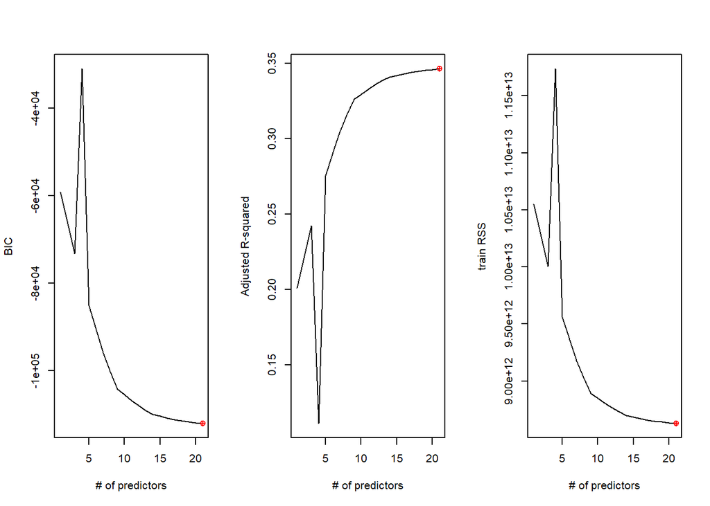

```r
par(mfrow=c(1,3))
bics<-summary(reg.stepnv20)$bic
plot(1:21,bics,type="l",ylab="BIC",xlab="# of predictors")
index<-which(bics==min(bics))
points(index,bics[index],col="red",pch=10)

adjr2<-summary(reg.stepnv20)$adjr2
plot(1:21,adjr2,type="l",ylab="Adjusted R-squared",xlab="# of predictors")
index<-which(adjr2==max(adjr2))
points(index,adjr2[index],col="red",pch=10)

rss<-summary(reg.stepnv20)$rss
plot(1:21,rss,type="l",ylab="train RSS",xlab="# of predictors")
index<-which(rss==min(rss))
points(index,rss[index],col="red",pch=10)
```

Splitt the data and do predictions

Observations: -We need 10+ predictors to get best fit -The predictions for test set is not very good.

```r
set.seed(1234)
index<-sample(1:dim(reports_serv_new)[1],100,replace=F)
train<-reports_serv_new[index,]
test<-reports_serv_new[-index,]
reg.fwd=regsubsets(ReportDeliveryTime~.,data=train,method="forward",nvmax=20)
```

```
## Reordering variables and trying again:
```

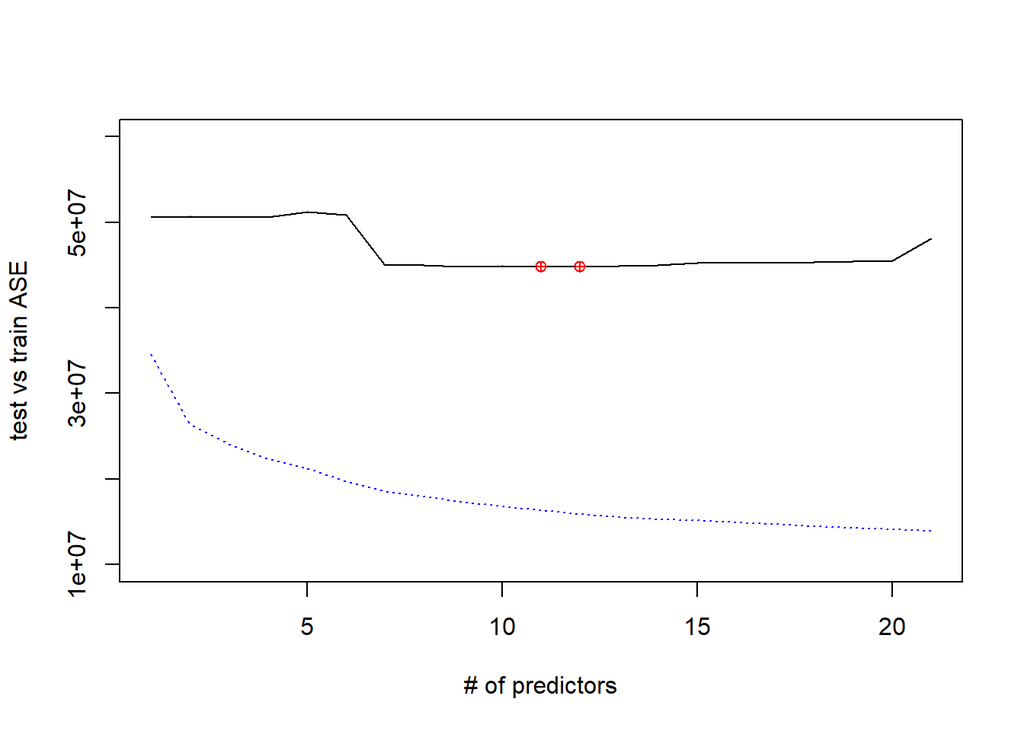

```r
predict.regsubsets =function (object , newdata ,id ,...){
  form=as.formula (object$call [[2]])
  mat=model.matrix(form ,newdata )
  coefi=coef(object ,id=id)
  xvars=names(coefi)
  mat[,xvars]%*%coefi
}

testASE<-c()
#note my index is to 20 since that what I set it in regsubsets
for (i in 1:21){
  predictions<-predict.regsubsets(object=reg.fwd,newdata=test,id=i)
  testASE[i]<-mean((test$ReportDeliveryTime-predictions)^2)
}
par(mfrow=c(1,1))
plot(1:21,testASE,type="l",xlab="# of predictors",ylab="test vs train ASE",ylim=c(10000000,60000000))
index<-which(testASE==min(testASE))
points(index,testASE[index],col="red",pch=10)
rss<-summary(reg.fwd)$rss
lines(1:21,rss/100,lty=3,col="blue")  #Dividing by 100 since ASE=RSS/sample size
```

Because we find serious imbalance in ReportDeliveryTime distribution, below we log transform the response variables.

```r
all_model_log<-lm(log(ReportDeliveryTime)~., data=reports_serv_new)
summary(all_model_log)
```

```
##
## Call:
## lm(formula = log(ReportDeliveryTime) ~ ., data = reports_serv_new)
##
## Residuals:
##      Min       1Q   Median       3Q      Max
## -26.4181  -0.8391   0.1743   0.8067   8.6163
##
## Coefficients:
##                                        Estimate Std. Error  t value Pr(>|t|)
## (Intercept)                           1.001e+01  3.200e-01   31.285  < 2e-16
## SchedFreqOneTime                     -1.707e+00  1.289e-02 -132.404  < 2e-16
## SchedFreqWeek                        -3.233e-01  1.291e-02  -25.045  < 2e-16
## ServerSQLODR3                         4.569e-03  7.263e-03    0.629 0.529284
## ServerSQLODR6                        -6.876e-02  6.841e-03  -10.052  < 2e-16
## RptFrmtEXCEL                         -1.018e-01  1.147e-02   -8.872  < 2e-16
## RptFrmtHTML4.0                       -3.456e-01  2.580e-01   -1.340 0.180349
## RptFrmtPDF                            1.711e-02  1.051e-02    1.628 0.103583
## RptFrmtTXT                            5.233e-02  1.387e-02    3.773 0.000161
## RptFrmtXML                            1.266e+00  3.219e-02   39.338  < 2e-16
## DelivMthdFTP                         -4.487e-01  3.801e-02  -11.805  < 2e-16
## DelivMthdWEB                          6.726e-02  3.573e-02    1.882 0.059809
## Priority2                            -4.473e-02  3.436e-02   -1.302 0.192906
## Priority3                             9.602e-01  3.981e-02   24.116  < 2e-16
## Priority10                            1.109e+00  2.372e-02   46.756  < 2e-16
## AgentCount                            7.213e-01  1.440e-02   50.102  < 2e-16
## GroupCount                           -1.448e-05  1.186e-06  -12.211  < 2e-16
## ReportCategoryClaims                  7.172e-02  2.066e-02    3.471 0.000519
## ReportCategoryEligibility            -2.847e-01  2.127e-02  -13.386  < 2e-16
## ReportCategoryExtract                 5.754e-01  2.188e-02   26.302  < 2e-16
## ReportCategoryFinance Billing        -1.035e-01  3.007e-02   -3.443 0.000576
## ReportCategoryFinance Commission      1.105e+00  3.180e-02   34.752  < 2e-16
## ReportCategoryMedical Management     -6.868e-01  3.551e-02  -19.341  < 2e-16
## ReportCategoryMetrics                -5.132e-01  2.345e-02  -21.885  < 2e-16
## ReportCategoryMiscellaneous          -1.072e+00  2.820e-02  -38.013  < 2e-16
## ReportCategoryProfessional Liability -9.109e-01  4.085e-02  -22.298  < 2e-16
## ReportCategoryReinsurance             8.039e-01  2.222e-02   36.175  < 2e-16
## DayOfMonth02                         -9.194e-01  1.573e-02  -58.434  < 2e-16
## DayOfMonth03                         -1.326e+00  1.770e-02  -74.926  < 2e-16
## DayOfMonth04                         -6.635e-01  1.822e-02  -36.428  < 2e-16
```

[output cut: 135 more lines]

```
## HourOfDay16                          ***
## HourOfDay17                          ***
## HourOfDay18                          ***
## HourOfDay19                          ***
## HourOfDay20                          ***
## HourOfDay21                          ***
## HourOfDay22                          ***
## HourOfDay23                          ***
## ---
## Signif. codes:  0 '***' 0.001 '**' 0.01 '*' 0.05 '.' 0.1 ' ' 1
##
## Residual standard error: 1.479 on 264059 degrees of freedom
##   (1 observation deleted due to missingness)
## Multiple R-squared:  0.5184, Adjusted R-squared:  0.5182
## F-statistic:  3343 on 85 and 264059 DF,  p-value: < 2.2e-16
```

```r
#par(mfrow=c(2,2))
#plot(all_model_log)

log.fwdnv20=regsubsets(log(ReportDeliveryTime)~.,data=reports_serv_new,method="forward",nvmax=20)
```

```
## Reordering variables and trying again:
```

```r
summary(log.fwdnv20)
```

```
## Subset selection object
## Call: regsubsets.formula(log(ReportDeliveryTime) ~ ., data = reports_serv_new,
##     method = "forward", nvmax = 20)
## 86 Variables  (and intercept)
##                                      Forced in Forced out
## SchedFreqOneTime                         FALSE      FALSE
## SchedFreqWeek                            FALSE      FALSE
## ServerSQLODR3                            FALSE      FALSE
## ServerSQLODR6                            FALSE      FALSE
## RptFrmtEXCEL                             FALSE      FALSE
## RptFrmtHTML4.0                           FALSE      FALSE
## RptFrmtPDF                               FALSE      FALSE
## RptFrmtTXT                               FALSE      FALSE
## RptFrmtXML                               FALSE      FALSE
## DelivMthdFTP                             FALSE      FALSE
```

[output cut: 540 more lines]

```r
summary(log.fwdnv20)$adjr2
```

```
##  [1] 0.1813076 0.2631694 0.3259663 0.3468908 0.3744156 0.3882511 0.3982550
##  [8] 0.4126105 0.4225621 0.4321738 0.4384966 0.4425467 0.4458413 0.4484290
## [15] 0.4509677 0.4528707 0.4546918 0.4562316 0.4578760 0.4593734 0.4607212
```

```r
summary(log.fwdnv20)$rss
```

```
##  [1] 982171.3 883959.7 808620.6 783515.0 750491.5 733890.8 721886.7 704662.4
##  [9] 692721.4 681188.1 673600.5 668739.3 664784.5 661677.7 658629.7 656344.4
## [17] 654157.3 652307.7 650332.6 648533.8 646914.5
```

```r
summary(log.fwdnv20)$bic
```

```
##  [1]  -52817.40  -80633.69 -104151.71 -112470.23 -123832.32 -129728.27
##  [7] -134072.07 -140438.53 -144940.52 -149362.89 -152309.16 -154209.87
## [13] -155764.12 -156988.96 -158196.09 -159101.73 -159970.89 -160706.34
## [19] -161494.86 -162213.99 -162861.86
```

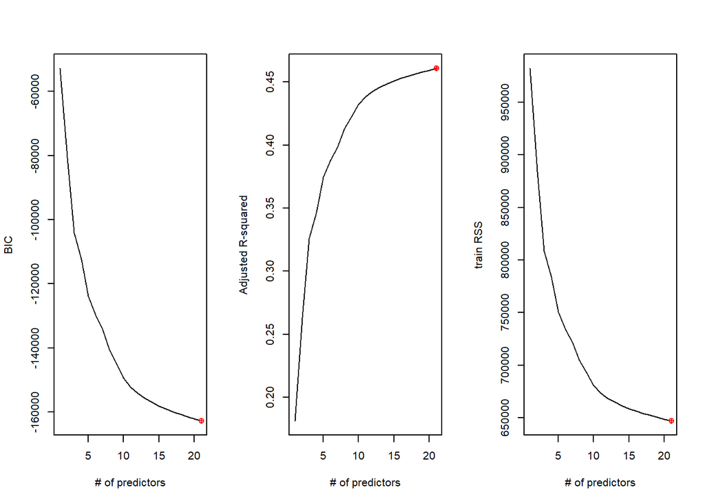

```r
par(mfrow=c(1,3))
bics<-summary(log.fwdnv20)$bic
plot(1:21,bics,type="l",ylab="BIC",xlab="# of predictors")
index<-which(bics==min(bics))
points(index,bics[index],col="red",pch=10)

adjr2<-summary(log.fwdnv20)$adjr2
plot(1:21,adjr2,type="l",ylab="Adjusted R-squared",xlab="# of predictors")
index<-which(adjr2==max(adjr2))
points(index,adjr2[index],col="red",pch=10)

rss<-summary(log.fwdnv20)$rss
plot(1:21,rss,type="l",ylab="train RSS",xlab="# of predictors")
index<-which(rss==min(rss))
points(index,rss[index],col="red",pch=10)
```

```r
coef(log.fwdnv20,10)
```

```
##                      (Intercept)                 SchedFreqOneTime
##                        7.5080915                       -2.9169421
##                    SchedFreqWeek                       RptFrmtPDF
##                       -1.0454292                        0.3041668
##                       AgentCount    ReportCategoryFinance Billing
##                        0.9298916                       -0.4987592
## ReportCategoryMedical Management                     DayOfMonth02
##                        0.0444671                        0.3269726
##                      HourOfDay07                      HourOfDay08
##                        0.1892339                       -0.5004287
##                      HourOfDay10
##                       -0.4852247
```

```r
#coef(log.stepnv20,10)

reports_serv_new <- filter(reports_serv_new, ReportDeliveryTime > 0)

#reg.final=regsubsets(log(ReportDeliveryTime)~.,data=reports_serv_new,method="forward",nvmax=20)
#coef(reg.final,3)
final.model<-lm(log(ReportDeliveryTime)~SchedFreq + RptFrmt + HourOfDay + DayOfMonth + ReportCategory + AgentCount,data=reports_serv_new)
summary(final.model)
```

```
##
## Call:
## lm(formula = log(ReportDeliveryTime) ~ SchedFreq + RptFrmt +
##     HourOfDay + DayOfMonth + ReportCategory + AgentCount, data = reports_serv_new)
##
## Residuals:
##      Min       1Q   Median       3Q      Max
## -23.8149  -0.8571   0.1801   0.8239   8.5614
##
## Coefficients:
##                                      Estimate Std. Error  t value Pr(>|t|)
## (Intercept)                          11.18503    0.32063   34.884  < 2e-16 ***
## SchedFreqOneTime                     -1.77342    0.01274 -139.155  < 2e-16 ***
## SchedFreqWeek                        -0.47149    0.01218  -38.716  < 2e-16 ***
## RptFrmtEXCEL                          0.02673    0.01062    2.517 0.011851 *
## RptFrmtHTML4.0                       -0.08819    0.26107   -0.338 0.735515
## RptFrmtPDF                            0.11909    0.01001   11.902  < 2e-16 ***
## RptFrmtTXT                           -0.26116    0.01090  -23.958  < 2e-16 ***
## RptFrmtXML                            0.94401    0.03040   31.050  < 2e-16 ***
## HourOfDay01                           0.03727    0.35581    0.105 0.916570
## HourOfDay02                          -0.14948    0.36312   -0.412 0.680598
## HourOfDay03                           0.13315    0.38688    0.344 0.730721
## HourOfDay04                           0.02298    0.35145    0.065 0.947874
## HourOfDay05                           0.19160    0.38961    0.492 0.622884
## HourOfDay06                          -1.16743    0.31984   -3.650 0.000262 ***
## HourOfDay07                          -2.52028    0.31999   -7.876 3.39e-15 ***
## HourOfDay08                          -3.15038    0.31995   -9.846  < 2e-16 ***
## HourOfDay09                          -2.64649    0.31994   -8.272  < 2e-16 ***
## HourOfDay10                          -3.42875    0.32007  -10.713  < 2e-16 ***
## HourOfDay11                          -3.59186    0.32018  -11.218  < 2e-16 ***
## HourOfDay12                          -3.91925    0.32029  -12.237  < 2e-16 ***
## HourOfDay13                          -3.92320    0.32015  -12.254  < 2e-16 ***
## HourOfDay14                          -3.80839    0.32022  -11.893  < 2e-16 ***
## HourOfDay15                          -3.43370    0.32019  -10.724  < 2e-16 ***
## HourOfDay16                          -3.49631    0.32040  -10.912  < 2e-16 ***
## HourOfDay17                          -4.21564    0.32060  -13.149  < 2e-16 ***
## HourOfDay18                          -3.79314    0.31987  -11.859  < 2e-16 ***
## HourOfDay19                          -3.27834    0.32044  -10.231  < 2e-16 ***
## HourOfDay20                          -3.89307    0.32345  -12.036  < 2e-16 ***
## HourOfDay21                          -4.51734    0.32144  -14.053  < 2e-16 ***
```

[output cut: 34 more lines]

```
## ReportCategoryExtract                 0.62413    0.02195   28.429  < 2e-16 ***
## ReportCategoryFinance Billing        -1.07121    0.02038  -52.570  < 2e-16 ***
## ReportCategoryFinance Commission      0.18015    0.02364    7.622 2.51e-14 ***
## ReportCategoryMedical Management     -0.75677    0.02109  -35.889  < 2e-16 ***
## ReportCategoryMetrics                -0.74073    0.02241  -33.056  < 2e-16 ***
## ReportCategoryMiscellaneous          -1.02618    0.02841  -36.125  < 2e-16 ***
## ReportCategoryProfessional Liability -1.92106    0.03557  -54.013  < 2e-16 ***
## ReportCategoryReinsurance             0.78968    0.02247   35.150  < 2e-16 ***
## AgentCount                            0.65165    0.01452   44.892  < 2e-16 ***
## ---
## Signif. codes:  0 '***' 0.001 '**' 0.01 '*' 0.05 '.' 0.1 ' ' 1
##
## Residual standard error: 1.498 on 264073 degrees of freedom
## Multiple R-squared:  0.5063, Adjusted R-squared:  0.5062
## F-statistic:  3814 on 71 and 264073 DF,  p-value: < 2.2e-16
```

```r
#plot(exp(final.model$fitted.values),reports_serv_new$ReportDeliveryTime,xlab="Predicted",ylab="ReportDeliveryTime",xlim=c(0,400000),ylim=c(0,400000))
#lines(c(0,400000),c(0,400000),col="red")
```

This is an effort of crease “binned” category variables.

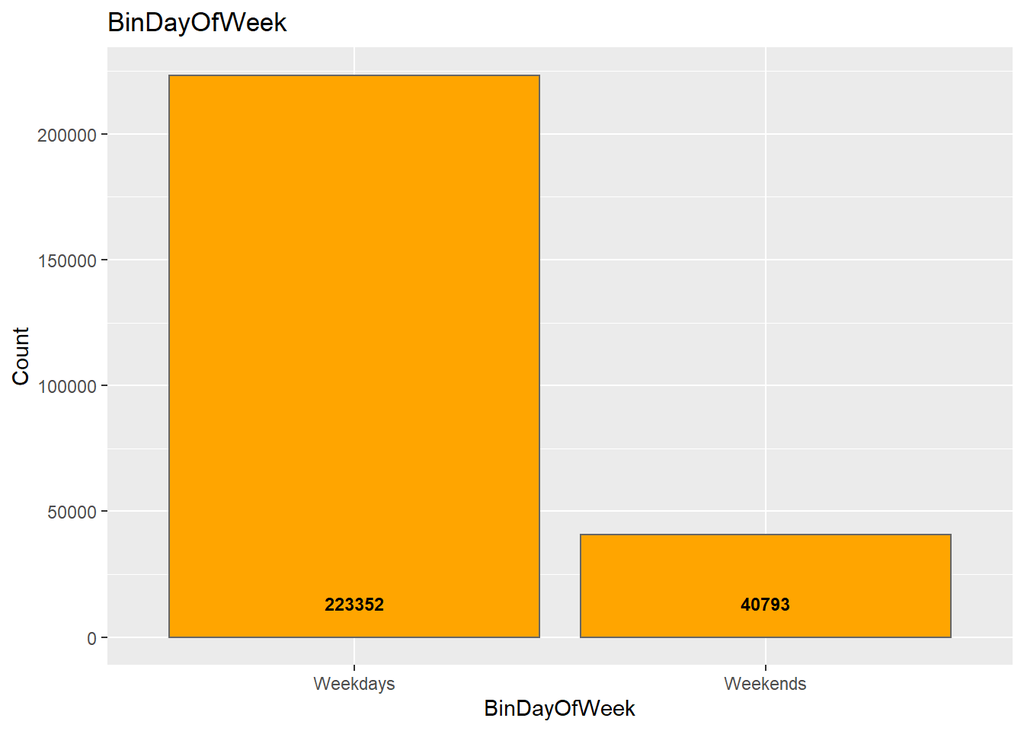

```r
reports_serv_bin <- reports_serv_new
reports_serv_bin$BinDayOfWeek <- case_when(reports_serv_new$DayOfWeek %in% c("Monday", "Tuesday","Wednesday","Thursday", "Friday") ~ "Weekdays",
          reports_serv_new$DayOfWeek %in% c("Saturday", "Sunday") ~ "Weekends")

#By BinDayOfWeek
reports_serv_bin %>% group_by(BinDayOfWeek) %>% dplyr::summarise(Count=n()) %>% ggplot(aes(x=BinDayOfWeek, y=Count)) + geom_bar(stat="identity", fill="orange", color="grey40") + labs(title="BinDayOfWeek", x="BinDayOfWeek",y="Count") + geom_text(aes(x=BinDayOfWeek, y=0.01, label= Count), vjust=-2, size=3, colour="black", fontface="bold",angle=360)
```

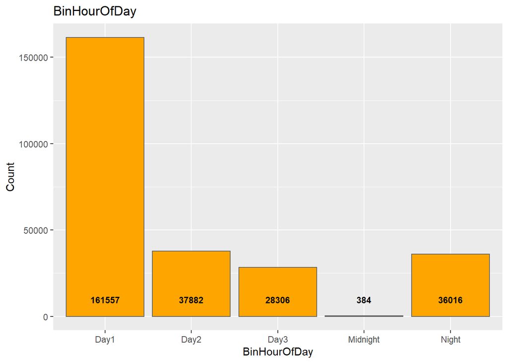

```r
reports_serv_bin$BinHourOfDay <- case_when(reports_serv_new$HourOfDay %in% c("00", "01","02","03", "04","05") ~ "Midnight",
          reports_serv_new$HourOfDay %in% c("06", "07","08","09") ~ "Day1",
          reports_serv_new$HourOfDay %in% c("10", "11","12","13") ~ "Day2",
          reports_serv_new$HourOfDay %in% c("14", "15","16","17") ~ "Day3",
          reports_serv_new$HourOfDay %in% c("18", "19","20","21","22","23") ~ "Night")


#By BinHourOfDay
reports_serv_bin %>% group_by(BinHourOfDay) %>% dplyr::summarise(Count=n()) %>% ggplot(aes(x=BinHourOfDay, y=Count)) + geom_bar(stat="identity", fill="orange", color="grey40") + labs(title="BinHourOfDay", x="BinHourOfDay",y="Count") + geom_text(aes(x=BinHourOfDay, y=0.01, label= Count), vjust=-2, size=3, colour="black", fontface="bold",angle=360)
```

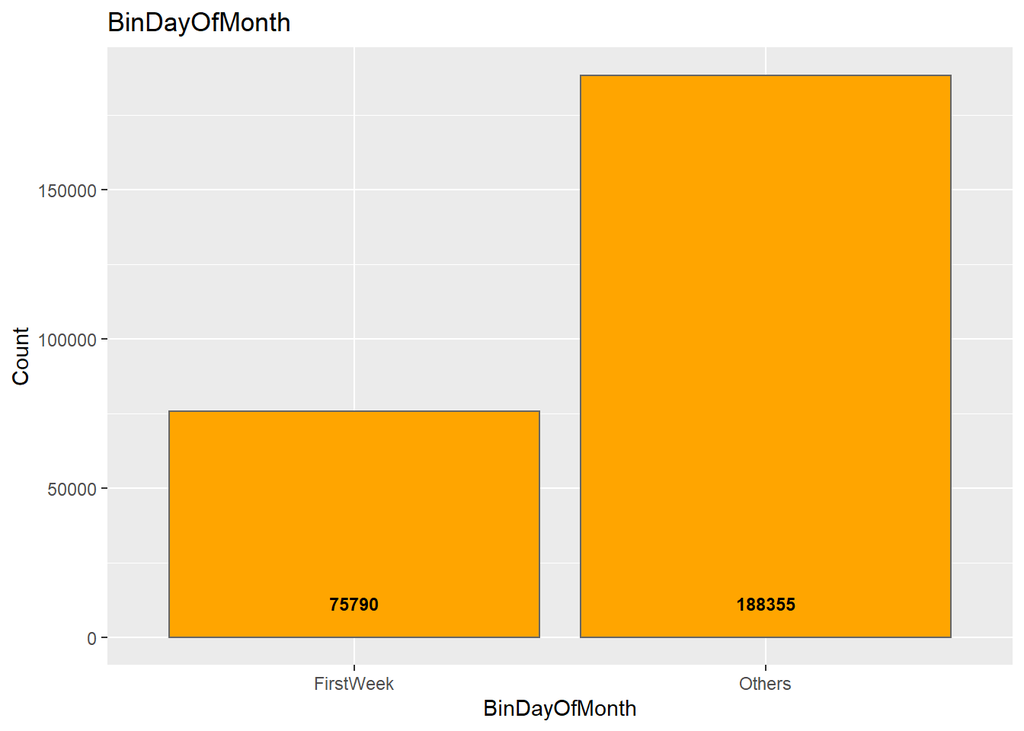

```r
reports_serv_bin$BinDayOfMonth <- case_when(reports_serv_new$DayOfMonth %in% c("01","02","03", "04","05") ~ "FirstWeek",
          TRUE ~ "Others")

#By BinDayOfMonth
reports_serv_bin %>% group_by(BinDayOfMonth) %>% dplyr::summarise(Count=n()) %>% ggplot(aes(x=BinDayOfMonth, y=Count)) + geom_bar(stat="identity", fill="orange", color="grey40") + labs(title="BinDayOfMonth", x="BinDayOfMonth",y="Count") + geom_text(aes(x=BinDayOfMonth, y=0.01, label= Count), vjust=-2, size=3, colour="black", fontface="bold",angle=360)
```

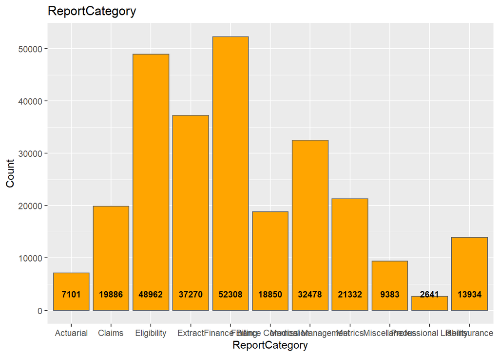

```r
reports_serv_bin %>% group_by(ReportCategory) %>% dplyr::summarise(Count=n()) %>% ggplot(aes(x=ReportCategory, y=Count)) + geom_bar(stat="identity", fill="orange", color="grey40") + labs(title="ReportCategory", x="ReportCategory",y="Count") + geom_text(aes(x=ReportCategory, y=0.01, label= Count), vjust=-2, size=3, colour="black", fontface="bold",angle=360)
```

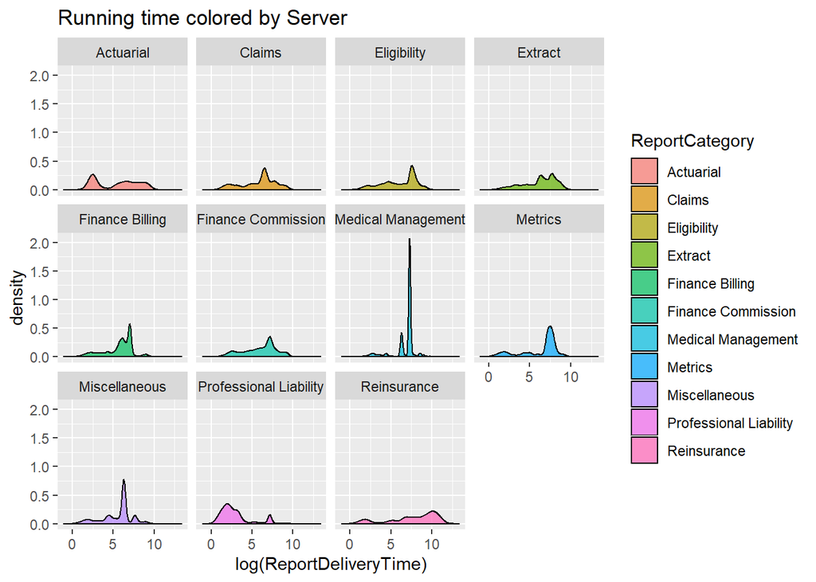

```r
reports_serv_bin %>% ggplot(aes(x=log(ReportDeliveryTime), fill=ReportCategory)) + geom_density(alpha = 0.7) + labs(title="Running time colored by Server") + facet_wrap(~ReportCategory)
```